# Risk Factor Analysis

## Outcome Variable

**Outcome Variable:** haz

## Predictor Variables

**Intervention Variable:** earlybf

**Adjustment Set:**

unadjusted

## Stratifying Variables

The analysis was stratified on these variable(s):

- agecat
- studyid
- country

## Data Summary

| agecat | studyid | country | earlybf | n_cell | n |
| --- | --- | --- | --- | --- | --- |
| Birth | ki0047075b-MAL-ED | BANGLADESH | 1 | 147 | 230 |
| Birth | ki0047075b-MAL-ED | BANGLADESH | 0 | 83 | 230 |
| Birth | ki0047075b-MAL-ED | BRAZIL | 1 | 28 | 65 |
| Birth | ki0047075b-MAL-ED | BRAZIL | 0 | 37 | 65 |
| Birth | ki0047075b-MAL-ED | INDIA | 1 | 32 | 46 |
| Birth | ki0047075b-MAL-ED | INDIA | 0 | 14 | 46 |
| Birth | ki0047075b-MAL-ED | NEPAL | 1 | 14 | 27 |
| Birth | ki0047075b-MAL-ED | NEPAL | 0 | 13 | 27 |
| Birth | ki0047075b-MAL-ED | PERU | 1 | 175 | 233 |
| Birth | ki0047075b-MAL-ED | PERU | 0 | 58 | 233 |
| Birth | ki0047075b-MAL-ED | SOUTH AFRICA | 1 | 69 | 111 |
| Birth | ki0047075b-MAL-ED | SOUTH AFRICA | 0 | 42 | 111 |
| Birth | ki0047075b-MAL-ED | TANZANIA, UNITED REPUBLIC OF | 1 | 111 | 125 |
| Birth | ki0047075b-MAL-ED | TANZANIA, UNITED REPUBLIC OF | 0 | 14 | 125 |
| Birth | ki1000109-EE | PAKISTAN | 1 | 44 | 229 |
| Birth | ki1000109-EE | PAKISTAN | 0 | 185 | 229 |
| Birth | ki1000304b-SAS-CompFeed | INDIA | 1 | 86 | 1207 |
| Birth | ki1000304b-SAS-CompFeed | INDIA | 0 | 1121 | 1207 |
| Birth | ki1017093c-NIH-Crypto | BANGLADESH | 1 | 634 | 732 |
| Birth | ki1017093c-NIH-Crypto | BANGLADESH | 0 | 98 | 732 |
| Birth | ki1113344-GMS-Nepal | NEPAL | 1 | 180 | 632 |
| Birth | ki1113344-GMS-Nepal | NEPAL | 0 | 452 | 632 |
| Birth | ki1126311-ZVITAMBO | ZIMBABWE | 1 | 6556 | 12354 |
| Birth | ki1126311-ZVITAMBO | ZIMBABWE | 0 | 5798 | 12354 |
| Birth | kiGH5241-JiVitA-3 | BANGLADESH | 1 | 236 | 22370 |
| Birth | kiGH5241-JiVitA-3 | BANGLADESH | 0 | 22134 | 22370 |
| Birth | kiGH5241-JiVitA-4 | BANGLADESH | 1 | 1912 | 2823 |
| Birth | kiGH5241-JiVitA-4 | BANGLADESH | 0 | 911 | 2823 |
| 6 months | ki0047075b-MAL-ED | BANGLADESH | 1 | 147 | 240 |
| 6 months | ki0047075b-MAL-ED | BANGLADESH | 0 | 93 | 240 |

[output cut: 52 more lines]

The following strata were considered:

- agecat: 24 months, studyid: ki0047075b-MAL-ED, country: BANGLADESH
- agecat: 24 months, studyid: ki0047075b-MAL-ED, country: BRAZIL
- agecat: 24 months, studyid: ki0047075b-MAL-ED, country: INDIA
- agecat: 24 months, studyid: ki0047075b-MAL-ED, country: NEPAL
- agecat: 24 months, studyid: ki0047075b-MAL-ED, country: PERU
- agecat: 24 months, studyid: ki0047075b-MAL-ED, country: SOUTH AFRICA
- agecat: 24 months, studyid: ki0047075b-MAL-ED, country: TANZANIA, UNITED REPUBLIC OF
- agecat: 24 months, studyid: ki1000109-EE, country: PAKISTAN
- agecat: 24 months, studyid: ki1017093c-NIH-Crypto, country: BANGLADESH
- agecat: 24 months, studyid: ki1113344-GMS-Nepal, country: NEPAL
- agecat: 24 months, studyid: ki1126311-ZVITAMBO, country: ZIMBABWE
- agecat: 24 months, studyid: kiGH5241-JiVitA-3, country: BANGLADESH
- agecat: 24 months, studyid: kiGH5241-JiVitA-4, country: BANGLADESH
- agecat: 6 months, studyid: ki0047075b-MAL-ED, country: BANGLADESH
- agecat: 6 months, studyid: ki0047075b-MAL-ED, country: BRAZIL
- agecat: 6 months, studyid: ki0047075b-MAL-ED, country: INDIA
- agecat: 6 months, studyid: ki0047075b-MAL-ED, country: NEPAL
- agecat: 6 months, studyid: ki0047075b-MAL-ED, country: PERU
- agecat: 6 months, studyid: ki0047075b-MAL-ED, country: SOUTH AFRICA
- agecat: 6 months, studyid: ki0047075b-MAL-ED, country: TANZANIA, UNITED REPUBLIC OF
- agecat: 6 months, studyid: ki1000109-EE, country: PAKISTAN
- agecat: 6 months, studyid: ki1000304b-SAS-CompFeed, country: INDIA
- agecat: 6 months, studyid: ki1017093c-NIH-Crypto, country: BANGLADESH
- agecat: 6 months, studyid: ki1113344-GMS-Nepal, country: NEPAL
- agecat: 6 months, studyid: ki1126311-ZVITAMBO, country: ZIMBABWE
- agecat: 6 months, studyid: kiGH5241-JiVitA-3, country: BANGLADESH
- agecat: 6 months, studyid: kiGH5241-JiVitA-4, country: BANGLADESH
- agecat: Birth, studyid: ki0047075b-MAL-ED, country: BANGLADESH
- agecat: Birth, studyid: ki0047075b-MAL-ED, country: BRAZIL
- agecat: Birth, studyid: ki0047075b-MAL-ED, country: INDIA
- agecat: Birth, studyid: ki0047075b-MAL-ED, country: NEPAL
- agecat: Birth, studyid: ki0047075b-MAL-ED, country: PERU
- agecat: Birth, studyid: ki0047075b-MAL-ED, country: SOUTH AFRICA
- agecat: Birth, studyid: ki0047075b-MAL-ED, country: TANZANIA, UNITED REPUBLIC OF
- agecat: Birth, studyid: ki1000109-EE, country: PAKISTAN
- agecat: Birth, studyid: ki1000304b-SAS-CompFeed, country: INDIA
- agecat: Birth, studyid: ki1017093c-NIH-Crypto, country: BANGLADESH
- agecat: Birth, studyid: ki1113344-GMS-Nepal, country: NEPAL
- agecat: Birth, studyid: ki1126311-ZVITAMBO, country: ZIMBABWE
- agecat: Birth, studyid: kiGH5241-JiVitA-3, country: BANGLADESH
- agecat: Birth, studyid: kiGH5241-JiVitA-4, country: BANGLADESH

### Dropped Strata

Some strata were dropped due to rare outcomes:

- agecat: 24 months, studyid: kiGH5241-JiVitA-3, country: BANGLADESH

## Methods Detail

We’re interested in the causal parameters $E[Y_a]$ for all values of $a \in \mathcal{A}$. These parameters represent the mean outcome if, possibly contrary to fact, we intervened to set all units to have $A=a$. Under the randomization and positivity assumptions, these are identified by the statistical parameters $\psi_a=E_W[E_{Y|A,W}(Y|A=a,W)]$. In addition, we’re interested in the mean of $Y$, $E[Y]$ under no intervention (the observed mean). We will estimate these parameters by using SuperLearner to fit the relevant likelihood factors – $E_{Y|A,W}(Y|A=a,W)$ and $p(A=a|W)$, and then updating our likelihood fit using a joint TMLE.

For unadjusted analyses ($W=\{\}$), initial likelihoods were estimated using Lrnr_glm to estimate the simple $E(Y|A)$ and Lrnr_mean to estimate $p(A)$. For adjusted analyses, a small library containing Lrnr_glmnet, Lrnr_xgboost, and Lrnr_mean was used.

Having estimated these parameters, we will then use the delta method to estimate relative risks and attributable risks relative to a prespecified baseline level of $A$.

# Results Detail

## Results Plots

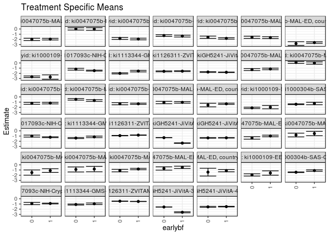

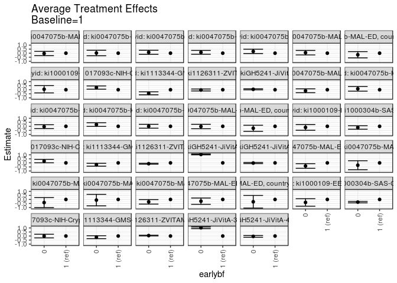

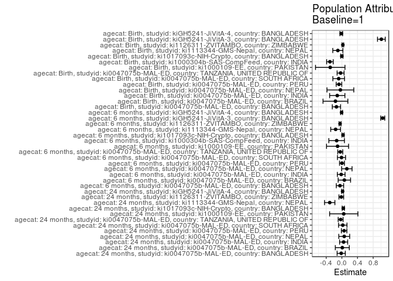

## Results Table

### Parameter: TSM

| agecat | studyid | country | intervention_level | baseline_level | estimate | ci_lower | ci_upper |
| --- | --- | --- | --- | --- | --- | --- | --- |
| Birth | ki0047075b-MAL-ED | BANGLADESH | 1 | NA | -0.9831293 | -1.1418402 | -0.8244183 |
| Birth | ki0047075b-MAL-ED | BANGLADESH | 0 | NA | -1.3674699 | -1.6045323 | -1.1304075 |
| Birth | ki0047075b-MAL-ED | BRAZIL | 1 | NA | -0.5121429 | -0.9312296 | -0.0930561 |
| Birth | ki0047075b-MAL-ED | BRAZIL | 0 | NA | -0.8000000 | -1.1619341 | -0.4380659 |
| Birth | ki0047075b-MAL-ED | INDIA | 1 | NA | -1.1046875 | -1.4653587 | -0.7440163 |
| Birth | ki0047075b-MAL-ED | INDIA | 0 | NA | -1.4907143 | -1.9921551 | -0.9892735 |
| Birth | ki0047075b-MAL-ED | NEPAL | 1 | NA | -0.8157143 | -1.3360253 | -0.2954033 |
| Birth | ki0047075b-MAL-ED | NEPAL | 0 | NA | -0.8938462 | -1.3789134 | -0.4087789 |
| Birth | ki0047075b-MAL-ED | PERU | 1 | NA | -0.8091429 | -0.9408117 | -0.6774740 |
| Birth | ki0047075b-MAL-ED | PERU | 0 | NA | -1.1050000 | -1.3497645 | -0.8602355 |
| Birth | ki0047075b-MAL-ED | SOUTH AFRICA | 1 | NA | -0.4901449 | -0.7157194 | -0.2645705 |
| Birth | ki0047075b-MAL-ED | SOUTH AFRICA | 0 | NA | -0.7035714 | -1.0225716 | -0.3845713 |
| Birth | ki0047075b-MAL-ED | TANZANIA, UNITED REPUBLIC OF | 1 | NA | -1.1235135 | -1.3393915 | -0.9076355 |
| Birth | ki0047075b-MAL-ED | TANZANIA, UNITED REPUBLIC OF | 0 | NA | -1.4100000 | -2.1608236 | -0.6591764 |
| Birth | ki1000109-EE | PAKISTAN | 1 | NA | -1.5745455 | -1.9860980 | -1.1629929 |
| Birth | ki1000109-EE | PAKISTAN | 0 | NA | -1.9419459 | -2.1591285 | -1.7247634 |
| Birth | ki1000304b-SAS-CompFeed | INDIA | 1 | NA | -1.1022093 | -1.2451037 | -0.9593149 |
| Birth | ki1000304b-SAS-CompFeed | INDIA | 0 | NA | -1.4306244 | -1.4938575 | -1.3673913 |
| Birth | ki1017093c-NIH-Crypto | BANGLADESH | 1 | NA | -0.9088644 | -0.9845542 | -0.8331745 |
| Birth | ki1017093c-NIH-Crypto | BANGLADESH | 0 | NA | -0.9135714 | -1.1256751 | -0.7014677 |
| Birth | ki1113344-GMS-Nepal | NEPAL | 1 | NA | -0.9553333 | -1.1059543 | -0.8047123 |
| Birth | ki1113344-GMS-Nepal | NEPAL | 0 | NA | -1.0986726 | -1.1981858 | -0.9991594 |
| Birth | ki1126311-ZVITAMBO | ZIMBABWE | 1 | NA | -0.5151678 | -0.5436558 | -0.4866798 |
| Birth | ki1126311-ZVITAMBO | ZIMBABWE | 0 | NA | -0.4605312 | -0.4941044 | -0.4269580 |
| Birth | kiGH5241-JiVitA-3 | BANGLADESH | 1 | NA | -2.5991949 | -2.6994048 | -2.4989851 |
| Birth | kiGH5241-JiVitA-3 | BANGLADESH | 0 | NA | -1.5789071 | -1.5983367 | -1.5594775 |
| Birth | kiGH5241-JiVitA-4 | BANGLADESH | 1 | NA | -1.5086140 | -1.5660250 | -1.4512031 |
| Birth | kiGH5241-JiVitA-4 | BANGLADESH | 0 | NA | -1.5540944 | -1.6467384 | -1.4614504 |
| 6 months | ki0047075b-MAL-ED | BANGLADESH | 1 | NA | -1.1572336 | -1.3068517 | -1.0076154 |
| 6 months | ki0047075b-MAL-ED | BANGLADESH | 0 | NA | -1.2821505 | -1.4717251 | -1.0925760 |
| 6 months | ki0047075b-MAL-ED | BRAZIL | 1 | NA | -0.0166842 | -0.2360157 | 0.2026473 |
| 6 months | ki0047075b-MAL-ED | BRAZIL | 0 | NA | 0.1011257 | -0.0886218 | 0.2908733 |
| 6 months | ki0047075b-MAL-ED | INDIA | 1 | NA | -1.1948214 | -1.3475968 | -1.0420460 |
| 6 months | ki0047075b-MAL-ED | INDIA | 0 | NA | -1.2358854 | -1.4228759 | -1.0488949 |
| 6 months | ki0047075b-MAL-ED | NEPAL | 1 | NA | -0.6890799 | -0.8531669 | -0.5249928 |
| 6 months | ki0047075b-MAL-ED | NEPAL | 0 | NA | -0.4741548 | -0.6253214 | -0.3229881 |
| 6 months | ki0047075b-MAL-ED | PERU | 1 | NA | -1.3265388 | -1.4535332 | -1.1995444 |
| 6 months | ki0047075b-MAL-ED | PERU | 0 | NA | -1.3154930 | -1.5202744 | -1.1107115 |
| 6 months | ki0047075b-MAL-ED | SOUTH AFRICA | 1 | NA | -1.0509081 | -1.2045229 | -0.8972934 |
| 6 months | ki0047075b-MAL-ED | SOUTH AFRICA | 0 | NA | -1.0747695 | -1.3030976 | -0.8464414 |
| 6 months | ki0047075b-MAL-ED | TANZANIA, UNITED REPUBLIC OF | 1 | NA | -1.3276423 | -1.4551737 | -1.2001108 |
| 6 months | ki0047075b-MAL-ED | TANZANIA, UNITED REPUBLIC OF | 0 | NA | -1.5693651 | -1.9200719 | -1.2186583 |
| 6 months | ki1000109-EE | PAKISTAN | 1 | NA | -1.9739951 | -2.2960356 | -1.6519546 |
| 6 months | ki1000109-EE | PAKISTAN | 0 | NA | -2.1093027 | -2.2389460 | -1.9796595 |
| 6 months | ki1000304b-SAS-CompFeed | INDIA | 1 | NA | -1.2686735 | -1.5069719 | -1.0303750 |
| 6 months | ki1000304b-SAS-CompFeed | INDIA | 0 | NA | -1.4123990 | -1.4871070 | -1.3376911 |
| 6 months | ki1017093c-NIH-Crypto | BANGLADESH | 1 | NA | -1.2285137 | -1.3049997 | -1.1520277 |
| 6 months | ki1017093c-NIH-Crypto | BANGLADESH | 0 | NA | -1.0063021 | -1.2011819 | -0.8114223 |
| 6 months | ki1113344-GMS-Nepal | NEPAL | 1 | NA | -1.1582450 | -1.3067598 | -1.0097303 |
| 6 months | ki1113344-GMS-Nepal | NEPAL | 0 | NA | -1.3843426 | -1.4816113 | -1.2870739 |
| 6 months | ki1126311-ZVITAMBO | ZIMBABWE | 1 | NA | -0.8162530 | -0.8527433 | -0.7797627 |
| 6 months | ki1126311-ZVITAMBO | ZIMBABWE | 0 | NA | -0.9165611 | -0.9573115 | -0.8758107 |
| 6 months | kiGH5241-JiVitA-3 | BANGLADESH | 1 | NA | -2.3574286 | -2.4045861 | -2.3102710 |
| 6 months | kiGH5241-JiVitA-3 | BANGLADESH | 0 | NA | -1.3109144 | -1.3345766 | -1.2872522 |
| 6 months | kiGH5241-JiVitA-4 | BANGLADESH | 1 | NA | -1.3382708 | -1.3839008 | -1.2926409 |
| 6 months | kiGH5241-JiVitA-4 | BANGLADESH | 0 | NA | -1.3564134 | -1.4152717 | -1.2975550 |
| 24 months | ki0047075b-MAL-ED | BANGLADESH | 1 | NA | -1.9572266 | -2.1128182 | -1.8016349 |
| 24 months | ki0047075b-MAL-ED | BANGLADESH | 0 | NA | -1.9987952 | -2.2142054 | -1.7833849 |
| 24 months | ki0047075b-MAL-ED | BRAZIL | 1 | NA | -0.0056458 | -0.2601558 | 0.2488641 |
| 24 months | ki0047075b-MAL-ED | BRAZIL | 0 | NA | 0.0166854 | -0.2075241 | 0.2408949 |
| 24 months | ki0047075b-MAL-ED | INDIA | 1 | NA | -1.9312687 | -2.0962922 | -1.7662451 |
| 24 months | ki0047075b-MAL-ED | INDIA | 0 | NA | -1.8212366 | -2.0109090 | -1.6315641 |
| 24 months | ki0047075b-MAL-ED | NEPAL | 1 | NA | -1.3685263 | -1.5429997 | -1.1940529 |
| 24 months | ki0047075b-MAL-ED | NEPAL | 0 | NA | -1.2640602 | -1.4262089 | -1.1019114 |
| 24 months | ki0047075b-MAL-ED | PERU | 1 | NA | -1.8101342 | -1.9520006 | -1.6682678 |
| 24 months | ki0047075b-MAL-ED | PERU | 0 | NA | -1.5872436 | -1.8139528 | -1.3605343 |
| 24 months | ki0047075b-MAL-ED | SOUTH AFRICA | 1 | NA | -1.6601794 | -1.8339614 | -1.4863974 |
| 24 months | ki0047075b-MAL-ED | SOUTH AFRICA | 0 | NA | -1.5990476 | -1.8160531 | -1.3820422 |
| 24 months | ki0047075b-MAL-ED | TANZANIA, UNITED REPUBLIC OF | 1 | NA | -2.6144444 | -2.7596542 | -2.4692347 |
| 24 months | ki0047075b-MAL-ED | TANZANIA, UNITED REPUBLIC OF | 0 | NA | -2.8102941 | -3.1696184 | -2.4509699 |
| 24 months | ki1000109-EE | PAKISTAN | 1 | NA | -2.7164583 | -3.1395766 | -2.2933401 |
| 24 months | ki1000109-EE | PAKISTAN | 0 | NA | -2.6560354 | -2.8056681 | -2.5064026 |
| 24 months | ki1017093c-NIH-Crypto | BANGLADESH | 1 | NA | -1.4788262 | -1.5712207 | -1.3864316 |
| 24 months | ki1017093c-NIH-Crypto | BANGLADESH | 0 | NA | -1.2069014 | -1.3827976 | -1.0310052 |
| 24 months | ki1113344-GMS-Nepal | NEPAL | 1 | NA | -1.5693511 | -1.7184566 | -1.4202457 |
| 24 months | ki1113344-GMS-Nepal | NEPAL | 0 | NA | -2.0087208 | -2.1187833 | -1.8986584 |
| 24 months | ki1126311-ZVITAMBO | ZIMBABWE | 1 | NA | -1.5858926 | -1.6730547 | -1.4987305 |
| 24 months | ki1126311-ZVITAMBO | ZIMBABWE | 0 | NA | -1.6159797 | -1.7027600 | -1.5291994 |
| 24 months | kiGH5241-JiVitA-4 | BANGLADESH | 1 | NA | -1.7995957 | -1.8440949 | -1.7550964 |
| 24 months | kiGH5241-JiVitA-4 | BANGLADESH | 0 | NA | -1.7471462 | -1.8011092 | -1.6931831 |

### Parameter: E(Y)

| agecat | studyid | country | intervention_level | baseline_level | estimate | ci_lower | ci_upper |
| --- | --- | --- | --- | --- | --- | --- | --- |
| Birth | ki0047075b-MAL-ED | BANGLADESH | NA | NA | -1.1218261 | -1.2566576 | -0.9869945 |
| Birth | ki0047075b-MAL-ED | BRAZIL | NA | NA | -0.6760000 | -0.9521457 | -0.3998543 |
| Birth | ki0047075b-MAL-ED | INDIA | NA | NA | -1.2221739 | -1.5203945 | -0.9239534 |
| Birth | ki0047075b-MAL-ED | NEPAL | NA | NA | -0.8533333 | -1.2104864 | -0.4961803 |
| Birth | ki0047075b-MAL-ED | PERU | NA | NA | -0.8827897 | -1.0001058 | -0.7654736 |
| Birth | ki0047075b-MAL-ED | SOUTH AFRICA | NA | NA | -0.5709009 | -0.7569265 | -0.3848753 |
| Birth | ki0047075b-MAL-ED | TANZANIA, UNITED REPUBLIC OF | NA | NA | -1.1556000 | -1.3655361 | -0.9456639 |
| Birth | ki1000109-EE | PAKISTAN | NA | NA | -1.8713537 | -2.0647180 | -1.6779894 |
| Birth | ki1000304b-SAS-CompFeed | INDIA | NA | NA | -1.4072245 | -1.4817853 | -1.3326638 |
| Birth | ki1017093c-NIH-Crypto | BANGLADESH | NA | NA | -0.9094945 | -0.9809370 | -0.8380521 |
| Birth | ki1113344-GMS-Nepal | NEPAL | NA | NA | -1.0578481 | -1.1411010 | -0.9745953 |
| Birth | ki1126311-ZVITAMBO | ZIMBABWE | NA | NA | -0.4895257 | -0.5113672 | -0.4676841 |
| Birth | kiGH5241-JiVitA-3 | BANGLADESH | NA | NA | -1.5896710 | -1.6089649 | -1.5703770 |
| Birth | kiGH5241-JiVitA-4 | BANGLADESH | NA | NA | -1.5232908 | -1.5723277 | -1.4742539 |
| 6 months | ki0047075b-MAL-ED | BANGLADESH | NA | NA | -1.2056389 | -1.3233420 | -1.0879358 |
| 6 months | ki0047075b-MAL-ED | BRAZIL | NA | NA | 0.0475758 | -0.0963508 | 0.1915023 |
| 6 months | ki0047075b-MAL-ED | INDIA | NA | NA | -1.2115254 | -1.3298727 | -1.0931782 |
| 6 months | ki0047075b-MAL-ED | NEPAL | NA | NA | -0.5615819 | -0.6741832 | -0.4489807 |
| 6 months | ki0047075b-MAL-ED | PERU | NA | NA | -1.3236661 | -1.4316775 | -1.2156546 |
| 6 months | ki0047075b-MAL-ED | SOUTH AFRICA | NA | NA | -1.0598800 | -1.1885688 | -0.9311912 |
| 6 months | ki0047075b-MAL-ED | TANZANIA, UNITED REPUBLIC OF | NA | NA | -1.3687449 | -1.4907629 | -1.2467270 |
| 6 months | ki1000109-EE | PAKISTAN | NA | NA | -2.0838858 | -2.2054394 | -1.9623322 |
| 6 months | ki1000304b-SAS-CompFeed | INDIA | NA | NA | -1.4018563 | -1.4810585 | -1.3226541 |
| 6 months | ki1017093c-NIH-Crypto | BANGLADESH | NA | NA | -1.1986783 | -1.2700937 | -1.1272630 |
| 6 months | ki1113344-GMS-Nepal | NEPAL | NA | NA | -1.3175310 | -1.3993963 | -1.2356656 |
| 6 months | ki1126311-ZVITAMBO | ZIMBABWE | NA | NA | -0.8625370 | -0.8897591 | -0.8353150 |
| 6 months | kiGH5241-JiVitA-3 | BANGLADESH | NA | NA | -1.3130932 | -1.3362359 | -1.2899505 |
| 6 months | kiGH5241-JiVitA-4 | BANGLADESH | NA | NA | -1.3447940 | -1.3820261 | -1.3075620 |
| 24 months | ki0047075b-MAL-ED | BANGLADESH | NA | NA | -1.9735782 | -2.1004502 | -1.8467062 |
| 24 months | ki0047075b-MAL-ED | BRAZIL | NA | NA | 0.0061144 | -0.1625850 | 0.1748138 |
| 24 months | ki0047075b-MAL-ED | INDIA | NA | NA | -1.8861894 | -2.0110006 | -1.7613783 |
| 24 months | ki0047075b-MAL-ED | NEPAL | NA | NA | -1.3075877 | -1.4270718 | -1.1881037 |
| 24 months | ki0047075b-MAL-ED | PERU | NA | NA | -1.7524710 | -1.8736426 | -1.6312994 |
| 24 months | ki0047075b-MAL-ED | SOUTH AFRICA | NA | NA | -1.6365071 | -1.7722110 | -1.5008032 |
| 24 months | ki0047075b-MAL-ED | TANZANIA, UNITED REPUBLIC OF | NA | NA | -2.6455607 | -2.7807256 | -2.5103959 |
| 24 months | ki1000109-EE | PAKISTAN | NA | NA | -2.6678252 | -2.8138884 | -2.5217620 |
| 24 months | ki1017093c-NIH-Crypto | BANGLADESH | NA | NA | -1.4412646 | -1.5249156 | -1.3576135 |
| 24 months | ki1113344-GMS-Nepal | NEPAL | NA | NA | -1.8793783 | -1.9705101 | -1.7882464 |
| 24 months | ki1126311-ZVITAMBO | ZIMBABWE | NA | NA | -1.6006366 | -1.6621572 | -1.5391159 |
| 24 months | kiGH5241-JiVitA-4 | BANGLADESH | NA | NA | -1.7807218 | -1.8162478 | -1.7451958 |

### Parameter: ATE

| agecat | studyid | country | intervention_level | baseline_level | estimate | ci_lower | ci_upper |
| --- | --- | --- | --- | --- | --- | --- | --- |
| Birth | ki0047075b-MAL-ED | BANGLADESH | 1 | 1 | 0.0000000 | 0.0000000 | 0.0000000 |
| Birth | ki0047075b-MAL-ED | BANGLADESH | 0 | 1 | -0.3843406 | -0.6696260 | -0.0990553 |
| Birth | ki0047075b-MAL-ED | BRAZIL | 1 | 1 | 0.0000000 | 0.0000000 | 0.0000000 |
| Birth | ki0047075b-MAL-ED | BRAZIL | 0 | 1 | -0.2878571 | -0.8415990 | 0.2658847 |
| Birth | ki0047075b-MAL-ED | INDIA | 1 | 1 | 0.0000000 | 0.0000000 | 0.0000000 |
| Birth | ki0047075b-MAL-ED | INDIA | 0 | 1 | -0.3860268 | -1.0037052 | 0.2316516 |
| Birth | ki0047075b-MAL-ED | NEPAL | 1 | 1 | 0.0000000 | 0.0000000 | 0.0000000 |
| Birth | ki0047075b-MAL-ED | NEPAL | 0 | 1 | -0.0781319 | -0.7894783 | 0.6332146 |
| Birth | ki0047075b-MAL-ED | PERU | 1 | 1 | 0.0000000 | 0.0000000 | 0.0000000 |
| Birth | ki0047075b-MAL-ED | PERU | 0 | 1 | -0.2958571 | -0.5737894 | -0.0179249 |
| Birth | ki0047075b-MAL-ED | SOUTH AFRICA | 1 | 1 | 0.0000000 | 0.0000000 | 0.0000000 |
| Birth | ki0047075b-MAL-ED | SOUTH AFRICA | 0 | 1 | -0.2134265 | -0.6041245 | 0.1772715 |
| Birth | ki0047075b-MAL-ED | TANZANIA, UNITED REPUBLIC OF | 1 | 1 | 0.0000000 | 0.0000000 | 0.0000000 |
| Birth | ki0047075b-MAL-ED | TANZANIA, UNITED REPUBLIC OF | 0 | 1 | -0.2864865 | -1.0677287 | 0.4947558 |
| Birth | ki1000109-EE | PAKISTAN | 1 | 1 | 0.0000000 | 0.0000000 | 0.0000000 |
| Birth | ki1000109-EE | PAKISTAN | 0 | 1 | -0.3674005 | -0.8327431 | 0.0979421 |
| Birth | ki1000304b-SAS-CompFeed | INDIA | 1 | 1 | 0.0000000 | 0.0000000 | 0.0000000 |
| Birth | ki1000304b-SAS-CompFeed | INDIA | 0 | 1 | -0.3284151 | -0.4198705 | -0.2369598 |
| Birth | ki1017093c-NIH-Crypto | BANGLADESH | 1 | 1 | 0.0000000 | 0.0000000 | 0.0000000 |
| Birth | ki1017093c-NIH-Crypto | BANGLADESH | 0 | 1 | -0.0047071 | -0.2299113 | 0.2204972 |
| Birth | ki1113344-GMS-Nepal | NEPAL | 1 | 1 | 0.0000000 | 0.0000000 | 0.0000000 |
| Birth | ki1113344-GMS-Nepal | NEPAL | 0 | 1 | -0.1433392 | -0.3238650 | 0.0371866 |
| Birth | ki1126311-ZVITAMBO | ZIMBABWE | 1 | 1 | 0.0000000 | 0.0000000 | 0.0000000 |
| Birth | ki1126311-ZVITAMBO | ZIMBABWE | 0 | 1 | 0.0546366 | 0.0106056 | 0.0986675 |
| Birth | kiGH5241-JiVitA-3 | BANGLADESH | 1 | 1 | 0.0000000 | 0.0000000 | 0.0000000 |
| Birth | kiGH5241-JiVitA-3 | BANGLADESH | 0 | 1 | 1.0202878 | 0.9187716 | 1.1218040 |
| Birth | kiGH5241-JiVitA-4 | BANGLADESH | 1 | 1 | 0.0000000 | 0.0000000 | 0.0000000 |
| Birth | kiGH5241-JiVitA-4 | BANGLADESH | 0 | 1 | -0.0454804 | -0.1544825 | 0.0635217 |
| 6 months | ki0047075b-MAL-ED | BANGLADESH | 1 | 1 | 0.0000000 | 0.0000000 | 0.0000000 |
| 6 months | ki0047075b-MAL-ED | BANGLADESH | 0 | 1 | -0.1249170 | -0.3664208 | 0.1165869 |
| 6 months | ki0047075b-MAL-ED | BRAZIL | 1 | 1 | 0.0000000 | 0.0000000 | 0.0000000 |
| 6 months | ki0047075b-MAL-ED | BRAZIL | 0 | 1 | 0.1178099 | -0.1722081 | 0.4078279 |
| 6 months | ki0047075b-MAL-ED | INDIA | 1 | 1 | 0.0000000 | 0.0000000 | 0.0000000 |
| 6 months | ki0047075b-MAL-ED | INDIA | 0 | 1 | -0.0410640 | -0.2825298 | 0.2004019 |
| 6 months | ki0047075b-MAL-ED | NEPAL | 1 | 1 | 0.0000000 | 0.0000000 | 0.0000000 |
| 6 months | ki0047075b-MAL-ED | NEPAL | 0 | 1 | 0.2149251 | -0.0081800 | 0.4380302 |
| 6 months | ki0047075b-MAL-ED | PERU | 1 | 1 | 0.0000000 | 0.0000000 | 0.0000000 |
| 6 months | ki0047075b-MAL-ED | PERU | 0 | 1 | 0.0110458 | -0.2299169 | 0.2520085 |
| 6 months | ki0047075b-MAL-ED | SOUTH AFRICA | 1 | 1 | 0.0000000 | 0.0000000 | 0.0000000 |
| 6 months | ki0047075b-MAL-ED | SOUTH AFRICA | 0 | 1 | -0.0238614 | -0.2990544 | 0.2513317 |
| 6 months | ki0047075b-MAL-ED | TANZANIA, UNITED REPUBLIC OF | 1 | 1 | 0.0000000 | 0.0000000 | 0.0000000 |
| 6 months | ki0047075b-MAL-ED | TANZANIA, UNITED REPUBLIC OF | 0 | 1 | -0.2417228 | -0.6148978 | 0.1314521 |
| 6 months | ki1000109-EE | PAKISTAN | 1 | 1 | 0.0000000 | 0.0000000 | 0.0000000 |
| 6 months | ki1000109-EE | PAKISTAN | 0 | 1 | -0.1353076 | -0.4824639 | 0.2118487 |
| 6 months | ki1000304b-SAS-CompFeed | INDIA | 1 | 1 | 0.0000000 | 0.0000000 | 0.0000000 |
| 6 months | ki1000304b-SAS-CompFeed | INDIA | 0 | 1 | -0.1437256 | -0.3575331 | 0.0700819 |
| 6 months | ki1017093c-NIH-Crypto | BANGLADESH | 1 | 1 | 0.0000000 | 0.0000000 | 0.0000000 |
| 6 months | ki1017093c-NIH-Crypto | BANGLADESH | 0 | 1 | 0.2222116 | 0.0128597 | 0.4315636 |
| 6 months | ki1113344-GMS-Nepal | NEPAL | 1 | 1 | 0.0000000 | 0.0000000 | 0.0000000 |
| 6 months | ki1113344-GMS-Nepal | NEPAL | 0 | 1 | -0.2260976 | -0.4036302 | -0.0485649 |
| 6 months | ki1126311-ZVITAMBO | ZIMBABWE | 1 | 1 | 0.0000000 | 0.0000000 | 0.0000000 |
| 6 months | ki1126311-ZVITAMBO | ZIMBABWE | 0 | 1 | -0.1003081 | -0.1550085 | -0.0456077 |
| 6 months | kiGH5241-JiVitA-3 | BANGLADESH | 1 | 1 | 0.0000000 | 0.0000000 | 0.0000000 |
| 6 months | kiGH5241-JiVitA-3 | BANGLADESH | 0 | 1 | 1.0465142 | 0.9934505 | 1.0995779 |
| 6 months | kiGH5241-JiVitA-4 | BANGLADESH | 1 | 1 | 0.0000000 | 0.0000000 | 0.0000000 |
| 6 months | kiGH5241-JiVitA-4 | BANGLADESH | 0 | 1 | -0.0181425 | -0.0901389 | 0.0538539 |
| 24 months | ki0047075b-MAL-ED | BANGLADESH | 1 | 1 | 0.0000000 | 0.0000000 | 0.0000000 |
| 24 months | ki0047075b-MAL-ED | BANGLADESH | 0 | 1 | -0.0415686 | -0.3072947 | 0.2241575 |
| 24 months | ki0047075b-MAL-ED | BRAZIL | 1 | 1 | 0.0000000 | 0.0000000 | 0.0000000 |
| 24 months | ki0047075b-MAL-ED | BRAZIL | 0 | 1 | 0.0223312 | -0.3168519 | 0.3615144 |
| 24 months | ki0047075b-MAL-ED | INDIA | 1 | 1 | 0.0000000 | 0.0000000 | 0.0000000 |
| 24 months | ki0047075b-MAL-ED | INDIA | 0 | 1 | 0.1100321 | -0.1413807 | 0.3614449 |
| 24 months | ki0047075b-MAL-ED | NEPAL | 1 | 1 | 0.0000000 | 0.0000000 | 0.0000000 |
| 24 months | ki0047075b-MAL-ED | NEPAL | 0 | 1 | 0.1044662 | -0.1337211 | 0.3426535 |
| 24 months | ki0047075b-MAL-ED | PERU | 1 | 1 | 0.0000000 | 0.0000000 | 0.0000000 |
| 24 months | ki0047075b-MAL-ED | PERU | 0 | 1 | 0.2228906 | -0.0445475 | 0.4903288 |
| 24 months | ki0047075b-MAL-ED | SOUTH AFRICA | 1 | 1 | 0.0000000 | 0.0000000 | 0.0000000 |
| 24 months | ki0047075b-MAL-ED | SOUTH AFRICA | 0 | 1 | 0.0611318 | -0.2168818 | 0.3391453 |
| 24 months | ki0047075b-MAL-ED | TANZANIA, UNITED REPUBLIC OF | 1 | 1 | 0.0000000 | 0.0000000 | 0.0000000 |
| 24 months | ki0047075b-MAL-ED | TANZANIA, UNITED REPUBLIC OF | 0 | 1 | -0.1958497 | -0.5834058 | 0.1917065 |
| 24 months | ki1000109-EE | PAKISTAN | 1 | 1 | 0.0000000 | 0.0000000 | 0.0000000 |
| 24 months | ki1000109-EE | PAKISTAN | 0 | 1 | 0.0604230 | -0.3883743 | 0.5092203 |
| 24 months | ki1017093c-NIH-Crypto | BANGLADESH | 1 | 1 | 0.0000000 | 0.0000000 | 0.0000000 |
| 24 months | ki1017093c-NIH-Crypto | BANGLADESH | 0 | 1 | 0.2719248 | 0.0732385 | 0.4706111 |
| 24 months | ki1113344-GMS-Nepal | NEPAL | 1 | 1 | 0.0000000 | 0.0000000 | 0.0000000 |
| 24 months | ki1113344-GMS-Nepal | NEPAL | 0 | 1 | -0.4393697 | -0.6246969 | -0.2540425 |
| 24 months | ki1126311-ZVITAMBO | ZIMBABWE | 1 | 1 | 0.0000000 | 0.0000000 | 0.0000000 |
| 24 months | ki1126311-ZVITAMBO | ZIMBABWE | 0 | 1 | -0.0300871 | -0.1530832 | 0.0929091 |
| 24 months | kiGH5241-JiVitA-4 | BANGLADESH | 1 | 1 | 0.0000000 | 0.0000000 | 0.0000000 |
| 24 months | kiGH5241-JiVitA-4 | BANGLADESH | 0 | 1 | 0.0524495 | -0.0150883 | 0.1199872 |

### Parameter: PAR

| agecat | studyid | country | intervention_level | baseline_level | estimate | ci_lower | ci_upper |
| --- | --- | --- | --- | --- | --- | --- | --- |
| Birth | ki0047075b-MAL-ED | BANGLADESH | 1 | NA | -0.1386968 | -0.2443869 | -0.0330068 |
| Birth | ki0047075b-MAL-ED | BRAZIL | 1 | NA | -0.1638571 | -0.4809927 | 0.1532784 |
| Birth | ki0047075b-MAL-ED | INDIA | 1 | NA | -0.1174864 | -0.3125074 | 0.0775345 |
| Birth | ki0047075b-MAL-ED | NEPAL | 1 | NA | -0.0376190 | -0.3804478 | 0.3052097 |
| Birth | ki0047075b-MAL-ED | PERU | 1 | NA | -0.0736468 | -0.1447631 | -0.0025306 |
| Birth | ki0047075b-MAL-ED | SOUTH AFRICA | 1 | NA | -0.0807560 | -0.2298478 | 0.0683358 |
| Birth | ki0047075b-MAL-ED | TANZANIA, UNITED REPUBLIC OF | 1 | NA | -0.0320865 | -0.1210189 | 0.0568459 |
| Birth | ki1000109-EE | PAKISTAN | 1 | NA | -0.2968083 | -0.6732093 | 0.0795928 |
| Birth | ki1000304b-SAS-CompFeed | INDIA | 1 | NA | -0.3050152 | -0.3888263 | -0.2212042 |
| Birth | ki1017093c-NIH-Crypto | BANGLADESH | 1 | NA | -0.0006302 | -0.0307807 | 0.0295203 |
| Birth | ki1113344-GMS-Nepal | NEPAL | 1 | NA | -0.1025148 | -0.2317236 | 0.0266941 |
| Birth | ki1126311-ZVITAMBO | ZIMBABWE | 1 | NA | 0.0256421 | 0.0049719 | 0.0463124 |
| Birth | kiGH5241-JiVitA-3 | BANGLADESH | 1 | NA | 1.0095239 | 0.9105283 | 1.1085195 |
| Birth | kiGH5241-JiVitA-4 | BANGLADESH | 1 | NA | -0.0146768 | -0.0498076 | 0.0204540 |
| 6 months | ki0047075b-MAL-ED | BANGLADESH | 1 | NA | -0.0484053 | -0.1423056 | 0.0454949 |
| 6 months | ki0047075b-MAL-ED | BRAZIL | 1 | NA | 0.0642600 | -0.0941324 | 0.2226523 |
| 6 months | ki0047075b-MAL-ED | INDIA | 1 | NA | -0.0167040 | -0.1149612 | 0.0815533 |
| 6 months | ki0047075b-MAL-ED | NEPAL | 1 | NA | 0.1274979 | -0.0055392 | 0.2605350 |
| 6 months | ki0047075b-MAL-ED | PERU | 1 | NA | 0.0028727 | -0.0597979 | 0.0655433 |
| 6 months | ki0047075b-MAL-ED | SOUTH AFRICA | 1 | NA | -0.0089719 | -0.1124544 | 0.0945107 |
| 6 months | ki0047075b-MAL-ED | TANZANIA, UNITED REPUBLIC OF | 1 | NA | -0.0411027 | -0.1055642 | 0.0233588 |
| 6 months | ki1000109-EE | PAKISTAN | 1 | NA | -0.1098907 | -0.3918880 | 0.1721066 |
| 6 months | ki1000304b-SAS-CompFeed | INDIA | 1 | NA | -0.1331828 | -0.3323264 | 0.0659607 |
| 6 months | ki1017093c-NIH-Crypto | BANGLADESH | 1 | NA | 0.0298354 | 0.0011826 | 0.0584882 |
| 6 months | ki1113344-GMS-Nepal | NEPAL | 1 | NA | -0.1592860 | -0.2846779 | -0.0338940 |
| 6 months | ki1126311-ZVITAMBO | ZIMBABWE | 1 | NA | -0.0462840 | -0.0715485 | -0.0210195 |
| 6 months | kiGH5241-JiVitA-3 | BANGLADESH | 1 | NA | 1.0443354 | 0.9925501 | 1.0961206 |
| 6 months | kiGH5241-JiVitA-4 | BANGLADESH | 1 | NA | -0.0065232 | -0.0323973 | 0.0193509 |
| 24 months | ki0047075b-MAL-ED | BANGLADESH | 1 | NA | -0.0163516 | -0.1209150 | 0.0882118 |
| 24 months | ki0047075b-MAL-ED | BRAZIL | 1 | NA | 0.0117602 | -0.1668708 | 0.1903913 |
| 24 months | ki0047075b-MAL-ED | INDIA | 1 | NA | 0.0450792 | -0.0581638 | 0.1483223 |
| 24 months | ki0047075b-MAL-ED | NEPAL | 1 | NA | 0.0609386 | -0.0781654 | 0.2000426 |
| 24 months | ki0047075b-MAL-ED | PERU | 1 | NA | 0.0576632 | -0.0128348 | 0.1281613 |
| 24 months | ki0047075b-MAL-ED | SOUTH AFRICA | 1 | NA | 0.0236723 | -0.0840516 | 0.1313962 |
| 24 months | ki0047075b-MAL-ED | TANZANIA, UNITED REPUBLIC OF | 1 | NA | -0.0311163 | -0.0934368 | 0.0312042 |
| 24 months | ki1000109-EE | PAKISTAN | 1 | NA | 0.0486331 | -0.3126127 | 0.4098789 |
| 24 months | ki1017093c-NIH-Crypto | BANGLADESH | 1 | NA | 0.0375616 | 0.0089409 | 0.0661823 |
| 24 months | ki1113344-GMS-Nepal | NEPAL | 1 | NA | -0.3100271 | -0.4421172 | -0.1779371 |
| 24 months | ki1126311-ZVITAMBO | ZIMBABWE | 1 | NA | -0.0147439 | -0.0750224 | 0.0455345 |
| 24 months | kiGH5241-JiVitA-4 | BANGLADESH | 1 | NA | 0.0188739 | -0.0054654 | 0.0432132 |